# Notes on ‘Patterned and Plain Baked Clay in Pre-Pottery Contexts from Southeast Sulawesi, Indonesia’ by Bulbeck et al.

Ben Marwick

20 May 2018

# Introduction

In these notes I work through the paper to ensure I understand what is going on. I recompute some of the values, offer some observations where the ms. needs to be changed, and proposed some figures that we can add to the ms.

# Data and Code

I would like to deposit our spreadsheets and my R code (i.e. something like this document) on a publicly accessible trustworty data repository. I have created a repository for this paper here: http://doi.org/0.17605/OSF.IO/QF83X and added mentions to it in the paper. There’s nothing there yet, but I hope you will agree that this is worth to do. If we agree, I will upload the files at the same time that we submit to the journal.

## Radiocarbon ages

I used the table of C14 ages in the ms. and calibrated them using the R pkg Bchron (IntCal13 curve).

```r
# read in data
t_ages <- readxl::read_excel("../data/Talimbue_radiocarbon_ages.xlsx")

# clean columns
suppressPackageStartupMessages(library(tidyverse))
t_ages_clean <-
t_ages %>%
  mutate(Depth = if_else(str_detect(Depth, "cm"),
                         parse_number(Depth) / 100,
                         parse_number(Depth))) %>%
  mutate(`Date (BP)` = str_remove_all(`Date (BP)`, ",")) %>%
  separate(`Date (BP)`, into = c("age", "error")) %>%
  mutate_at(vars(age, error), as.numeric)
```

Here is the calibration code:

```r
# calibrate ages and plot
library(Bchron)

t_ages_clean_calibrated <-
BchronCalibrate(t_ages_clean$age,
                t_ages_clean$error,
                calCurves = rep('intcal13',
                                length(t_ages_clean$age)),
                positions = t_ages_clean$Depth)
```

I then fit a non-parametric chronology model to age/depth data according to the Compound Poisson-Gamma model defined by Haslett and Parnell (2008) DOI:10.1111/j.1467-9876.2008.00623.x

```r
t_out  = Bchronology(t_ages_clean$age,
                      t_ages_clean$error,
                      calCurves = rep('intcal13',
                                      length(t_ages_clean$age)),
                      positions = t_ages_clean$Depth,
                     )
```

Here is the plot showing the interpolated ages:

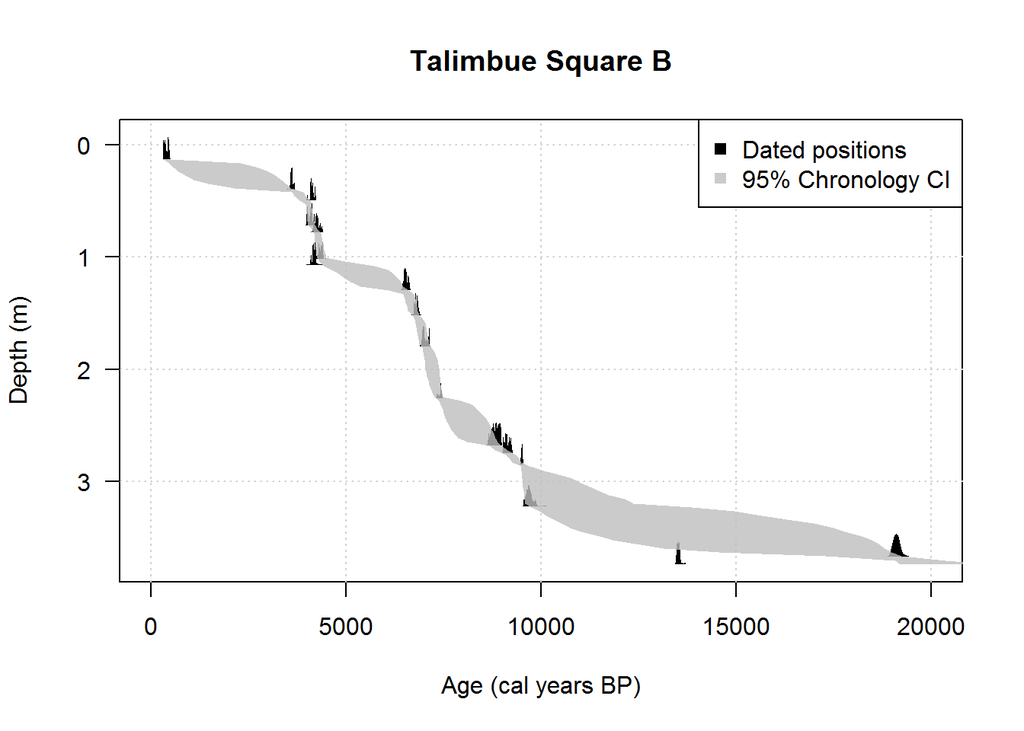

```r
# plot with age-position
plot(t_out,
     main="Talimbue Square B",
     xlab='Age (cal years BP)',
     ylab='Depth (m)',
     las=1,
     dateHeight = 0.2,
     legLoc = "topright",
     xlim = c(0, 20000))
```

I edited the plot by hand slightly to show the periods of rapid sedimentation, this is good because it clearly shows the uncertainties in our age-depth model:

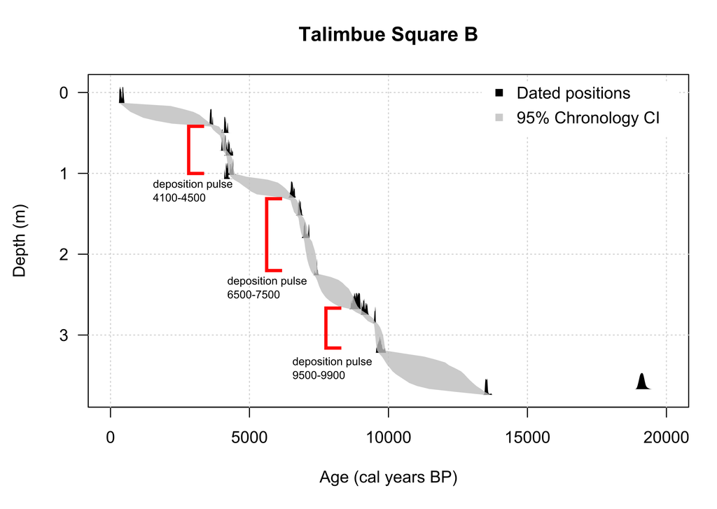

Using the chronology model computed above, I can predict ages for any depth in the site. We can use this to assign ages to the spits.

```r
# predict ages for a given depth
predictAges = predict(t_out,
                      newPositions = seq(0,
                                         max(t_ages_clean$Depth),
                                         by=0.001))

predictAges_means <- colMeans(predictAges)

predictAges_means_df <-
predictAges_means %>%
  as_data_frame()  %>%
  mutate(depth = as.numeric(str_remove(names(predictAges_means), "Pos"))) %>%
  rename(age = value)
```

## Spit depths and ages

I entered the spit depths from the recording sheets into an Excel file. I just used the depths recorded from the centre of the excavation square. For the lower depths that were not measured accurately I estimated a 0.05 m spit.

```r
# Square # depths for spits
t_sq_depths <- readxl::read_excel("../data/Spit depths from spit sheets.xlsx")

knitr::kable(t_sq_depths)
```

| spit | SQB_center_end_level | SQE_center_end_level | sq_e_cumul_depth_below_surface | sq_b_cumul_depth_below_surface |
| --- | --- | --- | --- | --- |
| 1 | 1.6200 | 1.560 | 0.070 | 0.0300 |
| 2 | 1.6600 | 1.610 | 0.120 | 0.0700 |
| 3 | 1.7000 | 1.660 | 0.170 | 0.1100 |
| 4 | 1.7600 | 1.700 | 0.210 | 0.1700 |
| 5 | 1.8200 | 1.745 | 0.255 | 0.2300 |
| 6 | 1.8800 | 1.795 | 0.305 | 0.2900 |
| 7 | 1.9400 | 1.855 | 0.365 | 0.3500 |
| 8 | 1.9750 | 1.900 | 0.410 | 0.3850 |
| 9 | 2.0150 | 1.970 | 0.480 | 0.4250 |
| 10 | 2.0750 | 2.015 | 0.525 | 0.4850 |
| 11 | 2.1150 | 2.075 | 0.585 | 0.5250 |
| 12 | 2.1500 | 2.125 | 0.635 | 0.5600 |
| 13 | 2.2050 | 2.200 | 0.710 | 0.6150 |
| 14 | 2.2500 | 2.260 | 0.770 | 0.6600 |
| 15 | 2.3150 | 2.300 | 0.810 | 0.7250 |
| 16 | 2.3800 | 2.345 | 0.855 | 0.7900 |
| 17 | 2.4000 | 2.410 | 0.920 | 0.8100 |
| 18 | 2.4850 | 2.445 | 0.955 | 0.8950 |
| 19 | 2.5400 | 2.510 | 1.020 | 0.9500 |
| 20 | 2.5800 | 2.580 | 1.090 | 0.9900 |
| 21 | 2.6450 | 2.615 | 1.125 | 1.0550 |
| 22 | 2.7500 | 2.660 | 1.170 | 1.1600 |
| 23 | 2.7650 | 2.710 | 1.220 | 1.1750 |
| 24 | 2.8400 | 2.745 | 1.255 | 1.2500 |
| 25 | 2.8950 | 2.810 | 1.320 | 1.3050 |
| 26 | 2.9400 | 2.870 | 1.380 | 1.3500 |
| 27 | 2.9900 | 2.925 | 1.435 | 1.4000 |
| 28 | 3.0500 | 2.975 | 1.485 | 1.4600 |
| 29 | 3.0900 | 3.030 | 1.540 | 1.5000 |
| 30 | 3.1800 | 3.080 | 1.590 | 1.5900 |

[output cut: 53 more lines]

# Densities of artefact and ecofact classes at Gua Talimbue Square B

We can plot this by depth or by age. Both are preferable to by Spit, because Spits are not ‘real’, for some peer-reviwers, at least.

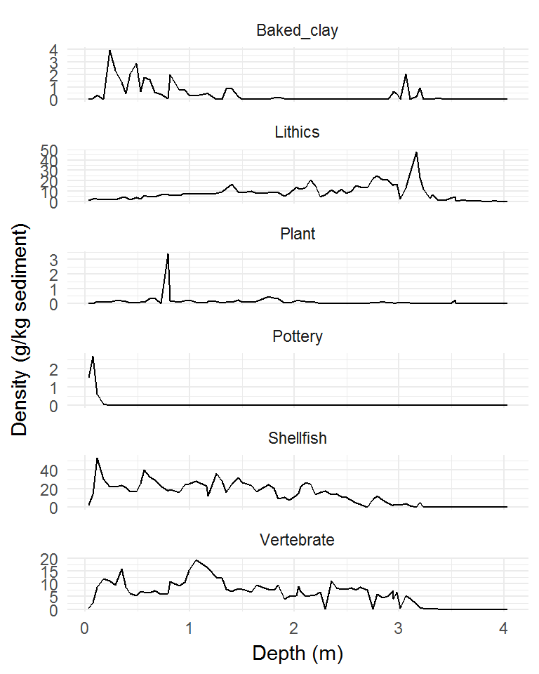

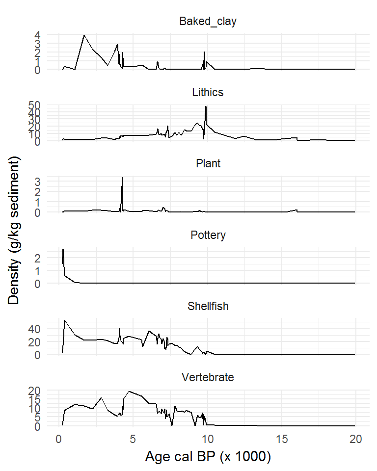

```r
# Square B artefact densities (n/kg sediment)
t_arts_sq_B <- readxl::read_excel("../data/Talimbue_weights_analysis.xlsx", sheet = "Talimbue_B_densities")

# Square # depths for spits
t_sq_depths <- readxl::read_excel("../data/Spit depths from spit sheets.xlsx")

# join sq B
t_arts_sq_B_join <-
  t_arts_sq_B %>%
  left_join(t_sq_depths,  # get depths for spits
            by = c("Spit" = "spit")) %>%
  # need 3 digits to match for the join
  mutate(sq_b_cumul_depth_below_surface = round(sq_b_cumul_depth_below_surface, 3)) %>%
  left_join(predictAges_means_df,  # get ages for depths
            by = c("sq_b_cumul_depth_below_surface" = "depth"))

# plot by depth
t_arts_sq_B_join %>%
  select(-Spit,
         -SQB_center_end_level,
         -SQE_center_end_level,
         -age,
         -sq_e_cumul_depth_below_surface) %>%
  gather(material, density, -sq_b_cumul_depth_below_surface) %>%
  ggplot(aes(sq_b_cumul_depth_below_surface,
             density)) +
  geom_line() +
  ylab("Density (g/kg sediment)") +
  xlab("Depth (m)") +
  facet_wrap( ~ material, scales = "free_y", ncol = 1) +
  theme_minimal()

# plot by age
t_arts_sq_B_join %>%
  select(-Spit,
         -SQB_center_end_level,
         -SQE_center_end_level,
         -sq_e_cumul_depth_below_surface,
         -sq_b_cumul_depth_below_surface) %>%
  gather(material, density, -age) %>%
  ggplot(aes(age/1000,
             density)) +
  geom_line() +
  ylab("Density (g/kg sediment)") +
  xlab("Age cal BP (x 1000)") +
  facet_wrap( ~ material, scales = "free_y", ncol = 1) +
  theme_minimal()
```

# Densities of artefact and ecofact classes at Gua Talimbue Square E.

I think we should use the density-age plots for the paper.

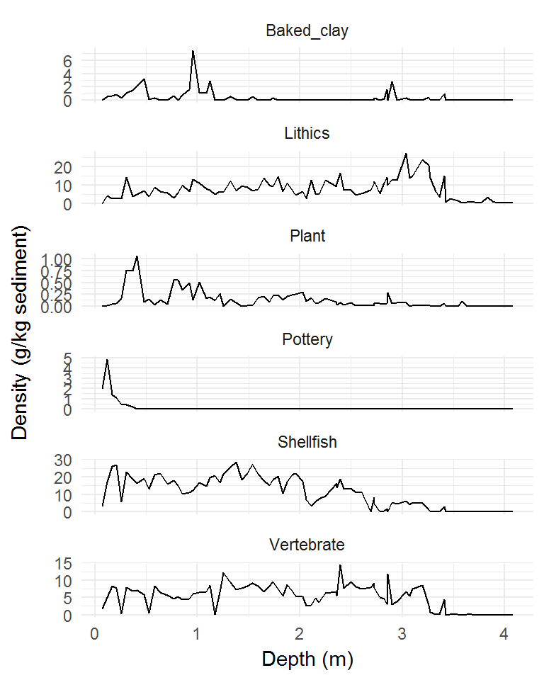

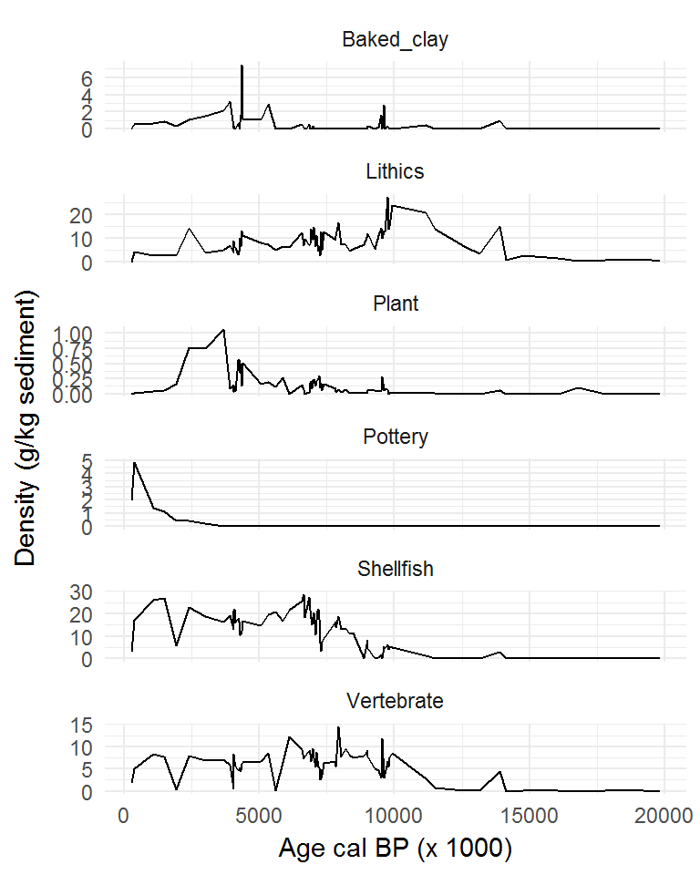

```r
# Square E artefact densities (n/kg sediment)
t_arts_sq_E <- readxl::read_excel("../data/Talimbue_weights_analysis.xlsx", sheet = "Talimbue_E_densities")

# join sq E
t_arts_sq_E_join <-
  t_arts_sq_E %>%
  left_join(t_sq_depths,  # get depths for spits
            by = c("Spit" = "spit")) %>%
  # need 3 digits to match for the join
  mutate(sq_e_cumul_depth_below_surface = round(sq_e_cumul_depth_below_surface, 3)) %>%
  left_join(predictAges_means_df,  # get ages for depths
            by = c("sq_e_cumul_depth_below_surface" = "depth"))


# plot densities by depth
t_arts_sq_E_join %>%
  select(-Spit,
         -SQB_center_end_level,
         -SQE_center_end_level,
         -age,
         -sq_b_cumul_depth_below_surface) %>%
  gather(material, density, -sq_e_cumul_depth_below_surface) %>%
  ggplot(aes(sq_e_cumul_depth_below_surface,
             density)) +
  geom_line() +
  ylab("Density (g/kg sediment)") +
  xlab("Depth (m)") +
  facet_wrap( ~ material, scales = "free_y", ncol = 1) +
  theme_minimal()

# plot densities by age
t_arts_sq_E_join %>%
  select(-Spit,
         -SQB_center_end_level,
         -SQE_center_end_level,
         -sq_e_cumul_depth_below_surface,
         -sq_b_cumul_depth_below_surface) %>%
  gather(material, density, -age) %>%
ggplot(aes(age,
           density)) +
  geom_line() +
  ylab("Density (g/kg sediment)") +
  xlab("Age cal BP (x 1000)") +
  facet_wrap( ~ material, scales = "free_y", ncol = 1) +
  theme_minimal()
```

# Correlation analysis of the Holocene artefact and ecofact densities (gm/kg of excavated sediment) from Gua Talimbue squares B and E

To check Table 2 in the ms. I explored some correlation and regression analyses. The plot below shows the Pearson’s correlation coefficient values, they match what we see in the table.

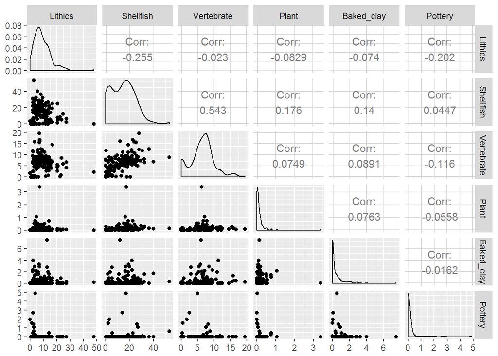

```r
Densities_for_regress_analysis <- readxl::read_excel("../data/Talimbue_weights_analysis.xlsx",
                  sheet = "Densities_for_regress_analysis")

d <- Densities_for_regress_analysis %>%
  select(Lithics,
         Shellfish,
         Vertebrate,
         Plant,
         Baked_clay,
         Pottery)

# check the distributions of all pairs of variables.
library(GGally)
ggpairs(d, progress = FALSE)
```

However, the plot above indicates that many of these variables are highly right-skewed. So we should use the more robust Spearman method for computing correlations, not Pearson:

```r
# should use spearman
library(corrr)
d %>%
  correlate(method = "spearman") %>%
  knitr::kable()
```

| rowname | Lithics | Shellfish | Vertebrate | Plant | Baked_clay | Pottery |
| --- | --- | --- | --- | --- | --- | --- |
| Lithics | NA | -0.1737911 | 0.0904063 | -0.0168325 | -0.1041656 | -0.3405242 |
| Shellfish | -0.1737911 | NA | 0.5702293 | 0.5053621 | 0.2326106 | 0.1287062 |
| Vertebrate | 0.0904063 | 0.5702293 | NA | 0.2844808 | 0.1219763 | -0.0420696 |
| Plant | -0.0168325 | 0.5053621 | 0.2844808 | NA | 0.2273079 | -0.0090374 |
| Baked_clay | -0.1041656 | 0.2326106 | 0.1219763 | 0.2273079 | NA | 0.1634124 |
| Pottery | -0.3405242 | 0.1287062 | -0.0420696 | -0.0090374 | 0.1634124 | NA |

We can get p-values for the correlations, and we see that about half of them do not return significant correlations. This is contrary to the table in the ms. I think the problem is that we have different methods to compute the t-statistic.

The t-statistic values I get here are quite different from in the ms. In the `Talimbue_weights_analysis.xlsx` spreadsheet, on sheet `Regression_analysis`, I see that you are computing the t-statistic using a formula like this `=D20*(139/(1-D20^2))` where `D20` is the cell with the *r* value, which we can write as

$$\frac {r(n-2)}{1-r^2}$$

. However, the [correct formula](https://onlinecourses.science.psu.edu/stat414/node/254/) for this is

$$\frac {r\sqrt{n-2}}{\sqrt{1-r^2}}$$

which in Excel, will look like `=(D20*SQRT(139))/SQRT(1-D20^2)`

What do you think? Do you have a source to confirm your method for computing the t-statistic? If it is wrote, we’ll need to redo some tables and edit the text a bit more.

Here is Pearson’s correlation, with p-values:

```r
# cor.test with p-values

var_pairs <- t(combn(names(d), 2)) %>%
  as_data_frame() %>%
  setNames(c("x", "y"))

cor_test <-
var_pairs %>%
  dplyr::mutate(r.test = purrr::map2(x, y,
                   ~ stats::cor.test(d[[.x]],
                                     d[[.y]],
                                    method ="pearson")),
                r.test = purrr::map(r.test, broom::tidy)) %>%
  tidyr::unnest(r.test) %>%
  select(-method, -alternative) %>%
  mutate_if(is.numeric, round, 3) %>%
  arrange(p.value)

knitr::kable(cor_test)
```

| x | y | estimate | statistic | p.value | parameter | conf.low | conf.high |
| --- | --- | --- | --- | --- | --- | --- | --- |
| Shellfish | Vertebrate | 0.543 | 7.625 | 0.000 | 139 | 0.415 | 0.650 |
| Lithics | Shellfish | -0.255 | -3.106 | 0.002 | 139 | -0.403 | -0.093 |
| Lithics | Pottery | -0.202 | -2.431 | 0.016 | 139 | -0.355 | -0.038 |
| Shellfish | Plant | 0.176 | 2.105 | 0.037 | 139 | 0.011 | 0.331 |
| Shellfish | Baked_clay | 0.140 | 1.671 | 0.097 | 139 | -0.026 | 0.299 |
| Vertebrate | Pottery | -0.116 | -1.375 | 0.171 | 139 | -0.276 | 0.050 |
| Vertebrate | Baked_clay | 0.089 | 1.055 | 0.293 | 139 | -0.077 | 0.251 |
| Lithics | Plant | -0.083 | -0.981 | 0.329 | 139 | -0.245 | 0.084 |
| Plant | Baked_clay | 0.076 | 0.903 | 0.368 | 139 | -0.090 | 0.239 |
| Vertebrate | Plant | 0.075 | 0.886 | 0.377 | 139 | -0.092 | 0.237 |
| Lithics | Baked_clay | -0.074 | -0.875 | 0.383 | 139 | -0.236 | 0.092 |
| Plant | Pottery | -0.056 | -0.659 | 0.511 | 139 | -0.219 | 0.110 |
| Shellfish | Pottery | 0.045 | 0.528 | 0.598 | 139 | -0.121 | 0.209 |
| Lithics | Vertebrate | -0.023 | -0.271 | 0.787 | 139 | -0.188 | 0.143 |
| Baked_clay | Pottery | -0.016 | -0.191 | 0.849 | 139 | -0.181 | 0.149 |

And here is Spearman, which I think is better for these data:

```r
# cor.test with p-values

var_pairs <- t(combn(names(d), 2)) %>%
  as_data_frame() %>%
  setNames(c("x", "y"))

cor_test <-
var_pairs %>%
  dplyr::mutate(r.test = purrr::map2(x, y,
                   ~ stats::cor.test(d[[.x]],
                                     d[[.y]],
                                    method ="spearman")),
                r.test = purrr::map(r.test, broom::tidy)) %>%
  tidyr::unnest(r.test) %>%
  select(-method, -alternative) %>%
  mutate_if(is.numeric, round, 3) %>%
  arrange(p.value)

knitr::kable(cor_test)
```

| x | y | estimate | statistic | p.value |
| --- | --- | --- | --- | --- |
| Lithics | Pottery | -0.341 | 626266.1 | 0.000 |
| Shellfish | Vertebrate | 0.570 | 200780.3 | 0.000 |
| Shellfish | Plant | 0.505 | 231085.0 | 0.000 |
| Vertebrate | Plant | 0.284 | 334276.3 | 0.001 |
| Shellfish | Baked_clay | 0.233 | 358509.0 | 0.006 |
| Plant | Baked_clay | 0.227 | 360986.3 | 0.007 |
| Lithics | Shellfish | -0.174 | 548371.7 | 0.039 |
| Baked_clay | Pottery | 0.163 | 390837.0 | 0.053 |
| Shellfish | Pottery | 0.129 | 407051.0 | 0.128 |
| Vertebrate | Baked_clay | 0.122 | 410195.1 | 0.150 |
| Lithics | Baked_clay | -0.104 | 515844.1 | 0.219 |
| Lithics | Vertebrate | 0.090 | 424944.0 | 0.286 |
| Vertebrate | Pottery | -0.042 | 486834.1 | 0.620 |
| Lithics | Plant | -0.017 | 475043.8 | 0.843 |
| Plant | Pottery | -0.009 | 471402.1 | 0.915 |

Let’s also look at linear regressions for each pair of variables. We see only four of these combinations have significant relationships.

```r
# check linear models
list_of_models <-
combn(names(d),
      2,
      function(x){lm(d[, x])}, simplify = FALSE)

vars <- combn(names(d), 2)
names(list_of_models) <- vars[1 , ]

table_of_lm_output <-
map_dfr(list_of_models, broom::glance) %>%
  mutate(var1 = vars[1, ]) %>%
  mutate(var2 = vars[2, ]) %>%
  select(var1, var2, everything()) %>%
  mutate_if(is.numeric, round, 3)  %>%
  arrange(p.value)

knitr::kable(table_of_lm_output)
```

| var1 | var2 | r.squared | adj.r.squared | sigma | statistic | p.value | df | logLik | AIC | BIC | deviance | df.residual |
| --- | --- | --- | --- | --- | --- | --- | --- | --- | --- | --- | --- | --- |
| Shellfish | Vertebrate | 0.295 | 0.290 | 8.456 | 58.143 | 0.000 | 2 | -500.077 | 1006.155 | 1015.001 | 9938.565 | 139 |
| Lithics | Shellfish | 0.065 | 0.058 | 6.378 | 9.649 | 0.002 | 2 | -460.323 | 926.645 | 935.492 | 5654.932 | 139 |
| Lithics | Pottery | 0.041 | 0.034 | 6.460 | 5.912 | 0.016 | 2 | -462.118 | 930.236 | 939.082 | 5800.762 | 139 |
| Shellfish | Plant | 0.031 | 0.024 | 9.913 | 4.433 | 0.037 | 2 | -522.501 | 1051.001 | 1059.848 | 13660.180 | 139 |
| Shellfish | Baked_clay | 0.020 | 0.013 | 9.971 | 2.792 | 0.097 | 2 | -523.312 | 1052.624 | 1061.470 | 13818.278 | 139 |
| Vertebrate | Pottery | 0.013 | 0.006 | 3.727 | 1.890 | 0.171 | 2 | -384.545 | 775.090 | 783.936 | 1930.284 | 139 |
| Vertebrate | Baked_clay | 0.008 | 0.001 | 3.737 | 1.113 | 0.293 | 2 | -384.935 | 775.870 | 784.716 | 1940.986 | 139 |
| Lithics | Plant | 0.007 | 0.000 | 6.573 | 0.961 | 0.329 | 2 | -464.568 | 935.137 | 943.983 | 6005.938 | 139 |
| Plant | Baked_clay | 0.006 | -0.001 | 0.319 | 0.815 | 0.368 | 2 | -37.832 | 81.664 | 90.510 | 14.119 | 139 |
| Vertebrate | Plant | 0.006 | -0.002 | 3.741 | 0.785 | 0.377 | 2 | -385.100 | 776.201 | 785.047 | 1945.548 | 139 |
| Lithics | Baked_clay | 0.005 | -0.002 | 6.578 | 0.765 | 0.383 | 2 | -464.667 | 935.334 | 944.181 | 6014.372 | 139 |
| Plant | Pottery | 0.003 | -0.004 | 0.319 | 0.435 | 0.511 | 2 | -38.024 | 82.048 | 90.894 | 14.157 | 139 |
| Shellfish | Pottery | 0.002 | -0.005 | 10.060 | 0.279 | 0.598 | 2 | -524.573 | 1055.145 | 1063.992 | 14067.619 | 139 |
| Lithics | Vertebrate | 0.001 | -0.007 | 6.594 | 0.073 | 0.787 | 2 | -465.017 | 936.034 | 944.880 | 6044.285 | 139 |
| Baked_clay | Pottery | 0.000 | -0.007 | 0.961 | 0.037 | 0.849 | 2 | -193.405 | 392.810 | 401.657 | 128.281 | 139 |

# Vertical distribution of Gua Talimbue patterned baked-clay fragments.

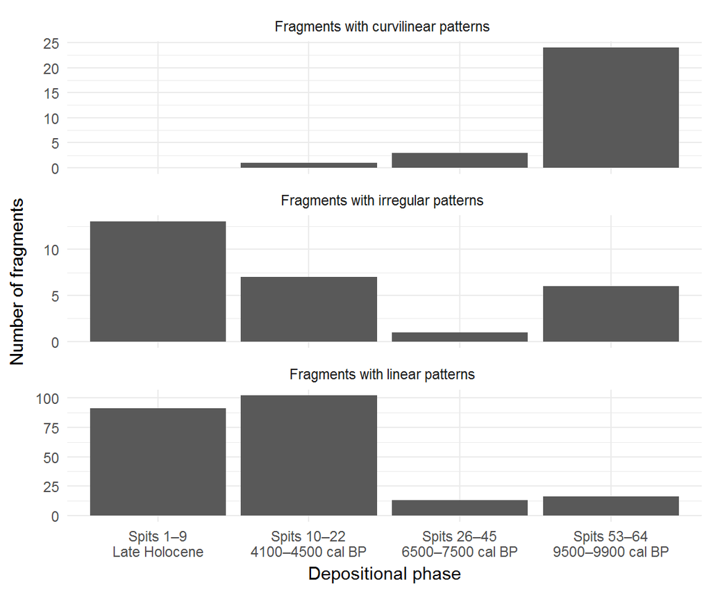

```r
t_vert_dist <- readxl::read_excel("../data/Talimbue_vertical_distribution_Gua_Talimbue_patterned_baked_clay_fragments.xlsx")

t_vert_dist %>%
  mutate(Spits = str_glue('Spits {Spits}\n{age}')) %>%
  select(Spits, ends_with("N")) %>%
  gather(variable, value, -Spits) %>%
  mutate(variable = str_remove_all(str_trim(variable),  "N")) %>%
  ggplot(aes(Spits,
             value)) +
  geom_col() +
  facet_wrap( ~ variable, ncol = 1, scales = "free_y") +
  theme_minimal() +
  ylab("Number of fragments") +
  xlab("Depositional phase")
```